# Marketing Analytics Assignment 1

### Imports

```r
    library(data.table) # library to use data.table objects
    library(stargazer)
```

```r
    library(ggplot2)
```

## Load data into R:

```r
dt.em <- fread("20210412-email-campaign.csv")
```

### Structure of the Data

Looking at the Structure of the Data

```r
    str(dt.em)
```

```
## Classes 'data.table' and 'data.frame':   45572 obs. of  11 variables:
##  $ last_purchase  : int  9 7 7 3 1 8 1 2 1 5 ...
##  $ hist_spend     : num  115.6 67.9 70.7 1221.9 512.4 ...
##  $ books          : int  0 0 0 1 1 1 0 1 0 1 ...
##  $ electronics    : int  1 1 1 1 1 0 1 0 1 1 ...
##  $ pop_density    : chr  "Rural" "Urban" "Suburban" "Suburban" ...
##  $ new_customer   : int  1 1 1 1 1 0 1 0 0 0 ...
##  $ device         : chr  "Mobile" "Mobile" "Mobile" "Laptop" ...
##  $ treatment      : chr  "Books Email" "Electronics Email" "No Email" "Books Email" ...
##  $ visit_after    : int  0 0 0 0 0 1 0 0 0 0 ...
##  $ purchased_after: int  0 0 0 0 0 0 0 0 0 0 ...
##  $ spend_after    : num  0 0 0 0 0 0 0 0 0 0 ...
##  - attr(*, ".internal.selfref")=<externalptr>
```

### Descriptive Statistics

#### 1. Summary of the Data - Stargazer & Summary

##### Numerical and Binary Variables:

- Last Purchase mean is around June (month 6), however there’s a large standard deviation and the distribution may not be normal.
- Historical spending (last year) has a very large standard deviation, we can infer that its distribution must be heavily skewed to with a long right tail given its large maximum value (3,345) and having 75% of all variables up to only 325.
- Electronics and books share approximatly the same mean, with both having more than 50% of customers buying the respective product. (we can infer this given it is a binomial variable and the mean will be the sum of all entries divided by all entries)
- new_customer is apparently perfectly balanced with an almost equal number of regular/old customers and new customers.

```r
    cat("\n Numerical Variables Summary Table\n")
```

```
##
##  Numerical Variables Summary Table
```

```r
    dt.em.predictors = dt.em[, list(last_purchase, hist_spend, books, electronics, pop_density, new_customer, device)]
    stargazer(dt.em.predictors, type="text")
```

```
##
## ========================================================================
## Statistic       N     Mean   St. Dev.  Min   Pctl(25) Pctl(75)    Max
## ------------------------------------------------------------------------
## last_purchase 45,572  5.764   3.505     1       2        9        12
## hist_spend    45,572 241.555 254.597  29.990  64.840  325.202  3,345.930
## books         45,572  0.550   0.498     0       0        1         1
## electronics   45,572  0.552   0.497     0       0        1         1
## new_customer  45,572  0.500   0.500     0       0        1         1
## ------------------------------------------------------------------------
```

```r
    cat("\n Categorical Variables Summary Table\n\n")
```

```
##
##  Categorical Variables Summary Table
```

```r
    summary(dt.em.predictors[, list(pop_density, device)])
```

```
##  pop_density           device
##  Length:45572       Length:45572
##  Class :character   Class :character
##  Mode  :character   Mode  :character
```

##### Categorical Variables:

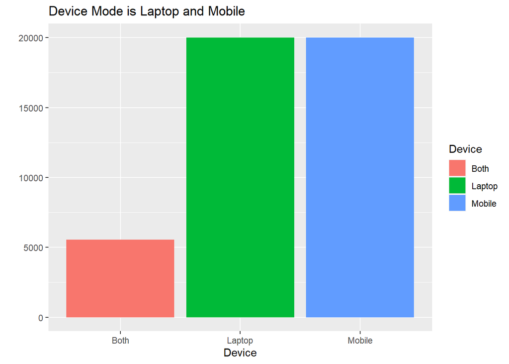

```r
    # check device mode
    qplot(factor(device), fill=factor(device), data=dt.em, geom="bar") +
     labs(title = "Device Mode is Laptop and Mobile",
              #subtitle = "Plot of length by dose",
              #caption = "Data source: ToothGrowth",
              x = "Device", y = "", fill="Device")
```

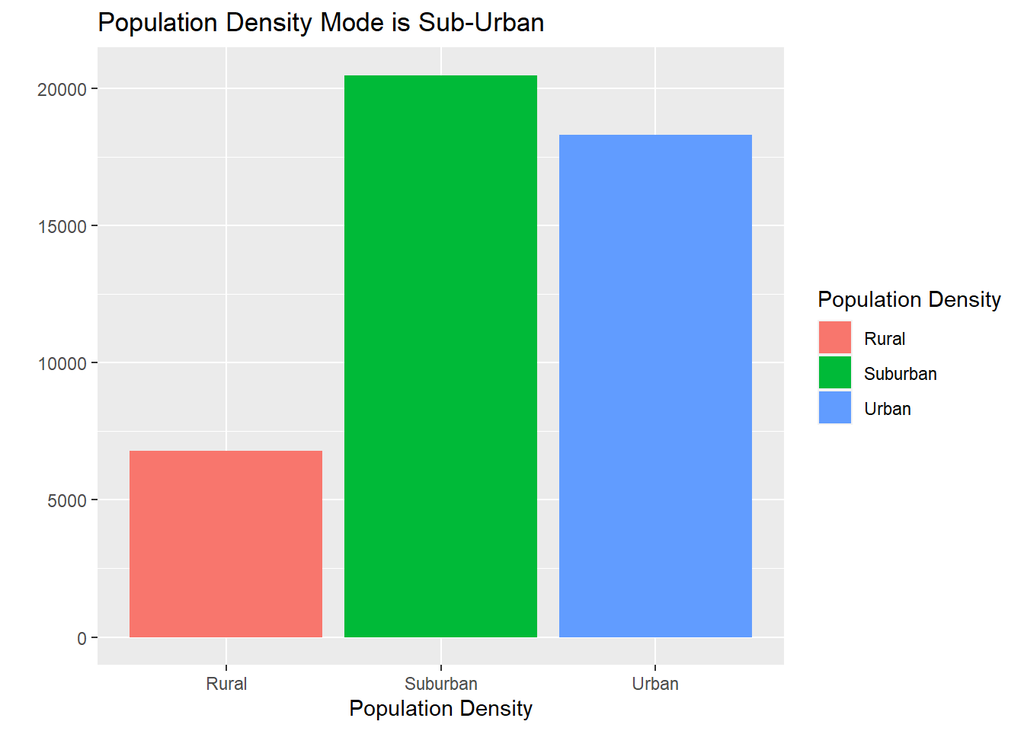

```r
    qplot(factor(pop_density), fill=factor(pop_density), data=dt.em, geom="bar") +
      labs(title = "Population Density Mode is Sub-Urban",
              #subtitle = "Plot of length by dose",
              #caption = "Data source: ToothGrowth",
              x = "Population Density", y = "", fill="Population Density")
```

## New Customer

- We want to evaluate the following questions:
1. When are customers (old and new) making their last purchases?
- Last purchases seem to have an increase in the last month of the year (here the number 1 given last_purchase is - months since last purchase - which coincides with Christmas season, where regular/old and new customers make the majority of their last purchases with new customers being the largest share of buyers for this month.
- This lead is sustained over regular custmers all the way back to September. Then regular customers become the largest share of last purchases as there is fewer and fewer poeple making their last purchases in the summer months of August through to May.
- In April and March we observe again a large number of last purchases from both regular/old customers, now with regular customers being the largest share of the respective months. Then in February and January we verify the lowest number of last purchases in the year.
- We should investigate if there is any external reason to prompt the increase in last purchases that early in the year (March and April). Perhaps Easter holidays can explain some of that increase.

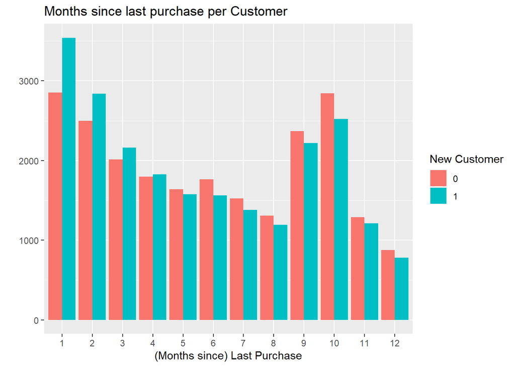

```r
    ggplot(data=dt.em, aes(factor(last_purchase), fill=factor(new_customer))) +
    geom_bar(position="dodge") + labs(title = "Months since last purchase per Customer",
              #subtitle = "Plot of length by dose",
              #caption = "Data source: ToothGrowth",
              x = "(Months since) Last Purchase", y = "", fill="New Customer")
```

2. Are new customers spending more than regular costumers?
- They are, by plotting the historical spending (last year’s spending) we have that new customers spend much more than regular/old customers with a longer right tail of the distribution.

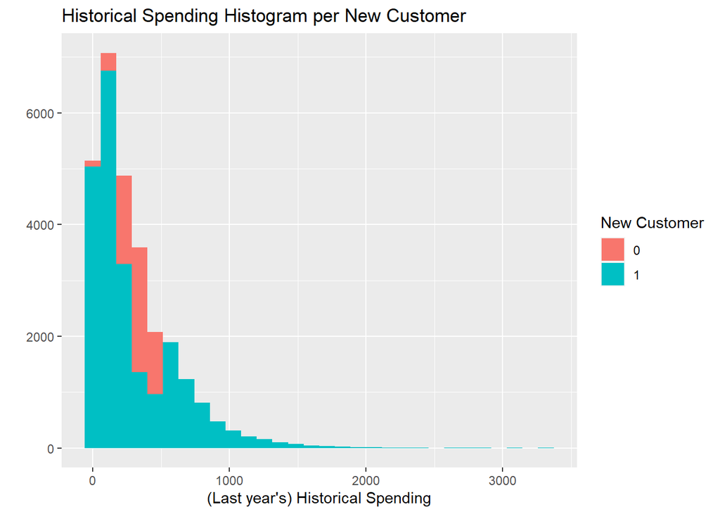

```r
    ggplot(data=dt.em, aes(hist_spend, fill = factor(new_customer))) + geom_histogram(alpha = 1, position = "identity") +
      labs(title = "Historical Spending Histogram per New Customer",
              #subtitle = "Plot of length by dose",
              #caption = "Data source: ToothGrowth",
              x = "(Last year's) Historical Spending", y = "", fill="New Customer")
```

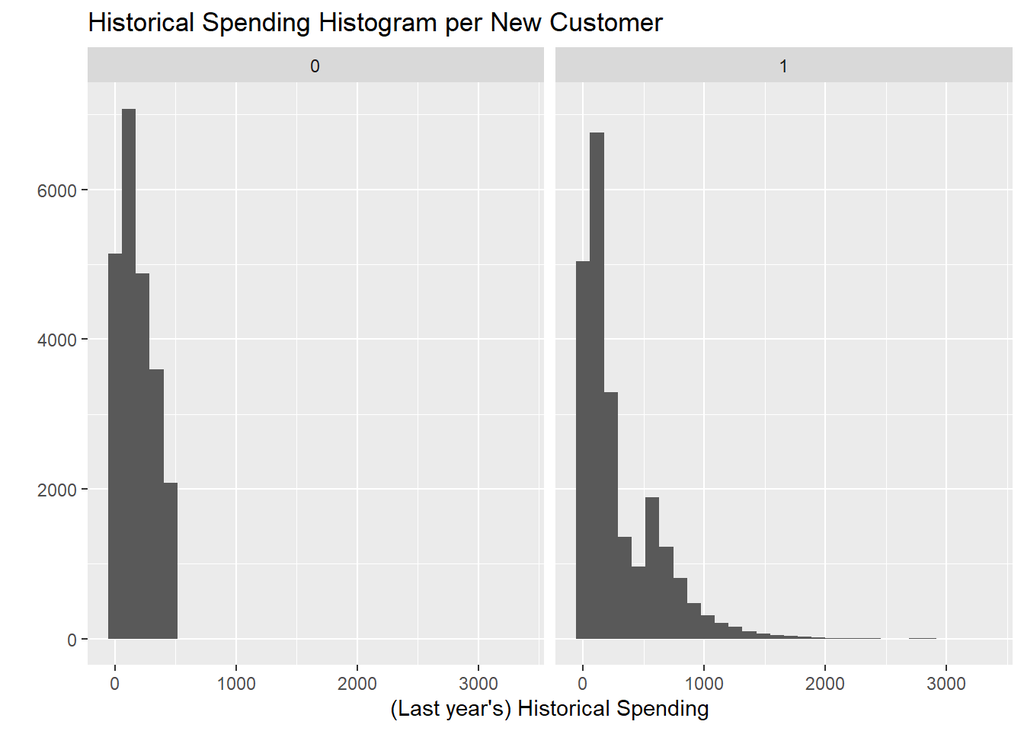

```r
    ggplot(data=dt.em, aes(hist_spend)) + geom_histogram(alpha = 1, position = "identity") + facet_wrap(~ new_customer) +
      labs(title = "Historical Spending Histogram per New Customer",
              #subtitle = "Plot of length by dose",
              #caption = "Data source: ToothGrowth",
              x = "(Last year's) Historical Spending", y = "", fill="New Customer")
```

This is what we call a “Power Law” distribution, so we can apply a log to see something closer to a normal distribution.

- What we can see is that a very large number of both regular/old and new customers spend a small amount, however, new customers spend more than regular ones. It even appears to exist a barrier of spending that is shared among a significant share of regular customers, around the 500 to 600$.
- This can be a factor when deciding which strategy to pursue for example: Should we work on retaining regular/old customers or focus on aquiring new customers?

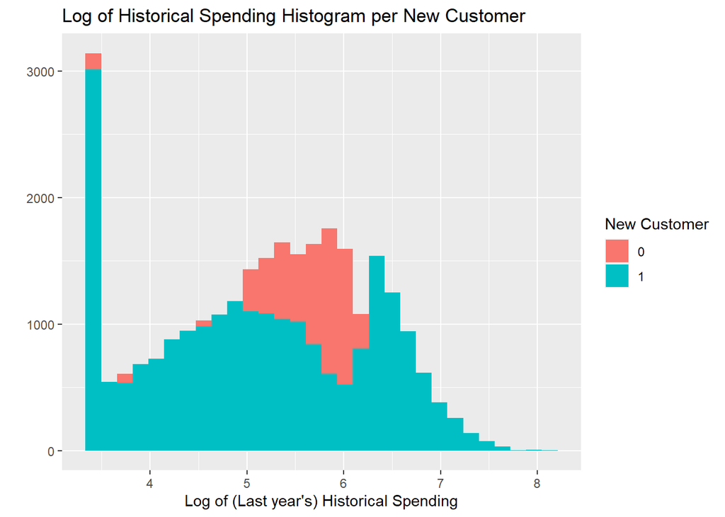

```r
     ggplot(data=dt.em, aes(log(hist_spend), fill = factor(new_customer))) + geom_histogram(alpha = 1, position = "identity") +
       labs(title = "Log of Historical Spending Histogram per New Customer",
              #subtitle = "Plot of length by dose",
              #caption = "Data source: ToothGrowth",
              x = "Log of (Last year's) Historical Spending", y = "", fill="New Customer")
```

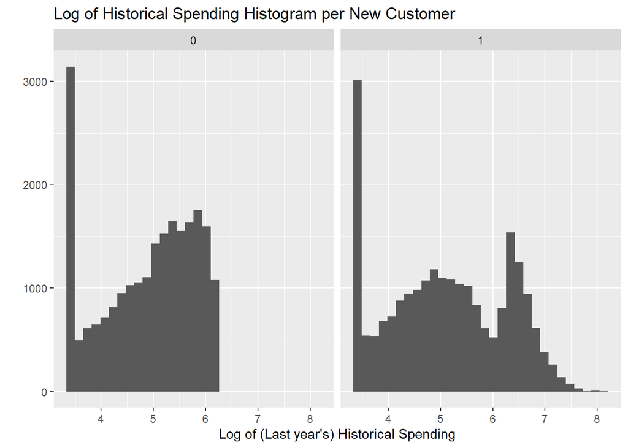

```r
     ggplot(data=dt.em, aes(log(hist_spend)))+ geom_histogram(alpha = 1, position = "identity") + facet_wrap(~ new_customer) +
       labs(title = "Log of Historical Spending Histogram per New Customer",
              #subtitle = "Plot of length by dose",
              #caption = "Data source: ToothGrowth",
              x = "Log of (Last year's) Historical Spending", y = "", fill="New Customer")
```

3. What is the relation betwenn new customers and books/electronics/device?

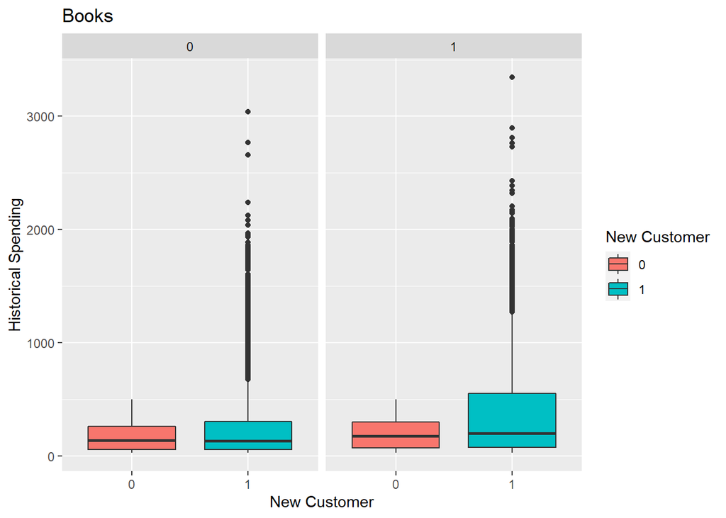

```r
    qplot(factor(new_customer), hist_spend, data=dt.em, fill=factor(new_customer), geom="boxplot") + facet_grid(~ books) +
      labs(title = "Books",
              #subtitle = "Plot of length by dose",
              #caption = "Data source: ToothGrowth",
              x = "New Customer", y = "Historical Spending", fill="New Customer")
```

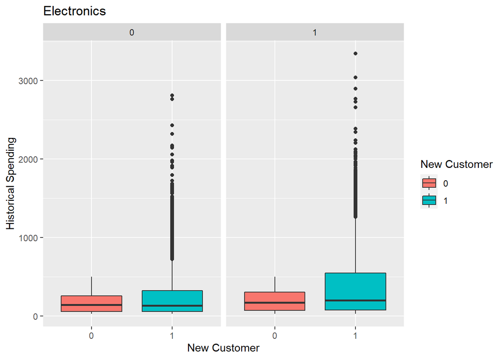

```r
    qplot(factor(new_customer), hist_spend, data=dt.em, fill=factor(new_customer), geom="boxplot") + facet_grid(~ electronics) +
      labs(title = "Electronics",
              #subtitle = "Plot of length by dose",
              #caption = "Data source: ToothGrowth",
              x = "New Customer", y = "Historical Spending", fill="New Customer")
```

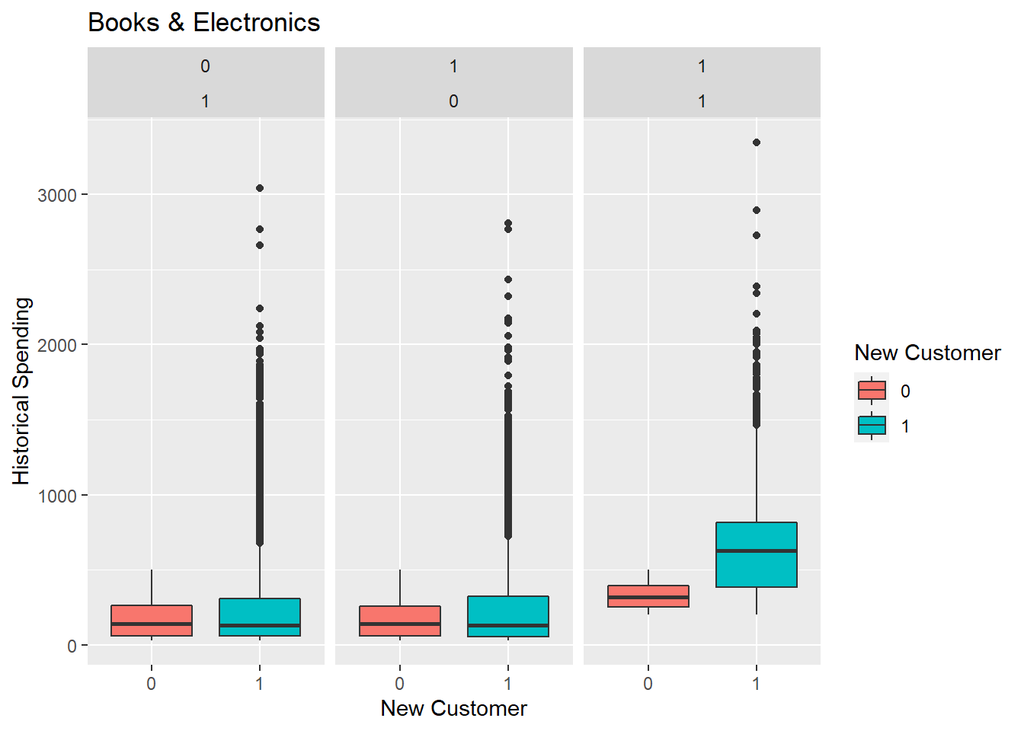

```r
    ggplot(dt.em, aes(x=factor(new_customer), y=hist_spend, fill=factor(new_customer))) + geom_boxplot() + facet_grid(~ books + electronics) +
      labs(title = "Books & Electronics",
              #subtitle = "Plot of length by dose",
              #caption = "Data source: ToothGrowth",
              x = "New Customer", y = "Historical Spending", fill="New Customer")
```

There seems to be a difference between means of new_customers per books and per electronics.

New customer seems to have a significant amount of outliers in spending, with the largest one being someone that bought both books and electronics last year. This tells us that for customers that buy either only books or only electronics last year, their distribution will have longer tails than that of a regular customer.

There also seems to be a difference in means between new_customer and both books and electronics.

```r
    t.test(dt.em$new_customer ~ dt.em$books)
```

```
##
##  Welch Two Sample t-test
##
## data:  dt.em$new_customer by dt.em$books
## t = -5.8381, df = 43806, p-value = 5.318e-09
## alternative hypothesis: true difference in means is not equal to 0
## 95 percent confidence interval:
##  -0.03669940 -0.01825089
## sample estimates:
## mean in group 0 mean in group 1
##       0.4853730       0.5128481
```

```r
    t.test(dt.em$new_customer ~ dt.em$electronics)
```

```
##
##  Welch Two Sample t-test
##
## data:  dt.em$new_customer by dt.em$electronics
## t = -3.3417, df = 43656, p-value = 0.0008334
## alternative hypothesis: true difference in means is not equal to 0
## 95 percent confidence interval:
##  -0.024968347 -0.006506955
## sample estimates:
## mean in group 0 mean in group 1
##       0.4917944       0.5075321
```

By performing the t-test we have that there seems to be a statistical significant differece between means.

```r
    lm.books.eletronics = lm(new_customer ~ books + electronics, data=dt.em)
    summary(lm.books.eletronics)
```

```
##
## Call:
## lm(formula = new_customer ~ books + electronics, data = dt.em)
##
## Residuals:
##     Min      1Q  Median      3Q     Max
## -0.6053 -0.4918  0.3947  0.5082  0.5146
##
## Coefficients:
##             Estimate Std. Error t value Pr(>|t|)
## (Intercept) 0.371876   0.008822   42.16   <2e-16 ***
## books       0.119918   0.008102   14.80   <2e-16 ***
## electronics 0.113497   0.008105   14.00   <2e-16 ***
## ---
## Signif. codes:  0 '***' 0.001 '**' 0.01 '*' 0.05 '.' 0.1 ' ' 1
##
## Residual standard error: 0.4988 on 45569 degrees of freedom
## Multiple R-squared:  0.005029,   Adjusted R-squared:  0.004985
## F-statistic: 115.2 on 2 and 45569 DF,  p-value: < 2.2e-16
```

By performing the F-test we can also see that books and electronics are jointly statistically significant

## Multilinear Regression (y = new_customer)

```r
    mfit = lm(new_customer ~ last_purchase + hist_spend + books + electronics + pop_density + device,
              data=dt.em)
    summary(mfit)
```

```
##
## Call:
## lm(formula = new_customer ~ last_purchase + hist_spend + books +
##     electronics + pop_density + device, data = dt.em)
##
## Residuals:
##     Min      1Q  Median      3Q     Max
## -0.9597 -0.4638 -0.3334  0.5331  0.6135
##
## Coefficients:
##                       Estimate Std. Error t value Pr(>|t|)
## (Intercept)          3.607e-01  1.379e-02  26.163  < 2e-16 ***
## last_purchase        3.849e-04  6.716e-04   0.573  0.56664
## hist_spend           4.723e-04  1.063e-05  44.440  < 2e-16 ***
## books               -2.008e-02  8.495e-03  -2.364  0.01810 *
## electronics         -2.630e-02  8.497e-03  -3.095  0.00197 **
## pop_densitySuburban  1.535e-02  6.827e-03   2.249  0.02452 *
## pop_densityUrban     1.030e-02  6.926e-03   1.487  0.13705
## deviceLaptop         3.760e-02  8.021e-03   4.687 2.77e-06 ***
## deviceMobile         4.895e-02  8.029e-03   6.097 1.09e-09 ***
## ---
## Signif. codes:  0 '***' 0.001 '**' 0.01 '*' 0.05 '.' 0.1 ' ' 1
##
## Residual standard error: 0.4872 on 45563 degrees of freedom
## Multiple R-squared:  0.05089,    Adjusted R-squared:  0.05072
## F-statistic: 305.4 on 8 and 45563 DF,  p-value: < 2.2e-16
```

By doing a multilinear regression to explain new_costumers we find that, ceteris paribus, hist_spend (last year expenditure) and device (laptop and mobile) are statistically significant at a 99.9% Confidence Interval. Interstingly, the time since last purchase is not statistically significant when it comes to explain new customers.

- We can also see that electronics seem to have a stronger statistical significance than books to explain older customers (given the negative sign of the coefficient), this could perhaps be explained by new customers having a higher trust on buying books than electronics at a new store.

## All Variables

ggpairs - Inspect relations between all combinations of variable pairs

```r
    library(GGally)
```

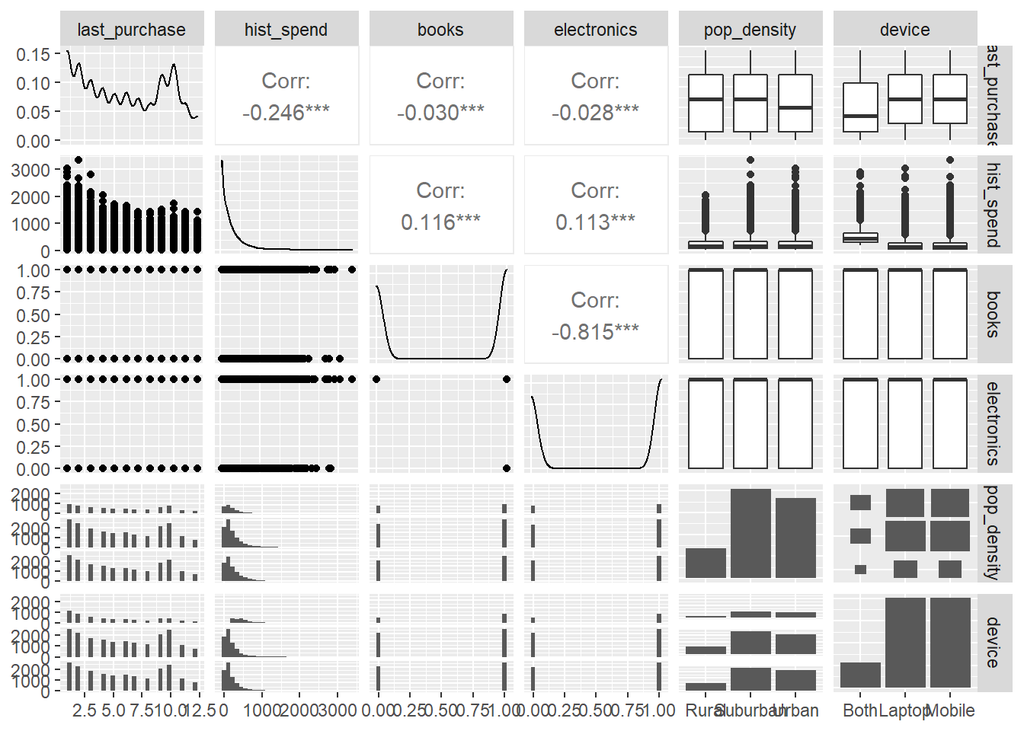

```r
    ggpairs(dt.em[, list(last_purchase, hist_spend, books, electronics, pop_density, device)])
```

- The correlation between historical spending (last year’s spending) and last purchase is statistically significant at -0.246. Therefore, there’s a weak negative correlation implying that we expect to have higher spending with customers that made their last purchase at the end of the year, which seems intuitive given that the end of the year has Christmas season a well know and planned expense for many customers. The weak correlation comes from the spike in March and April in the middle of the year, in what would otherwise be a downward trend throughout the year. It is important to reinforce the need to investigate what is causing such a significant increase in last purchases this early in the year, as the ideal would be to have a strong negative correlation between historical spending and time since last purchase as it would imply larger revenue for the company.
- Books and electronics slightly negative correlations with last_purchase suggest that there may be little influence in the timming of the last purchase and this being books or electronics, actually with this data it is necessarily one or the other, or both.
- Books and eletronics slightly positive correlation with historical spending (last year’s spending) which likely comes from having 2 out of 3 possible states of purchase. These are, (Books, No Electronics) , (No Books, Electronics) or (Books, Electronics). And as we can see in the Box plot for Books and Electronincs, there is a statistically significant difference in means, between old and new customers with the highest historical spending mean of all combinations coming from the purchase of both books and electronics.
- Books and electronics have a strong negative correlation, which is to be expected given that, as we can see below, only a small share of customers bough both products during the year.

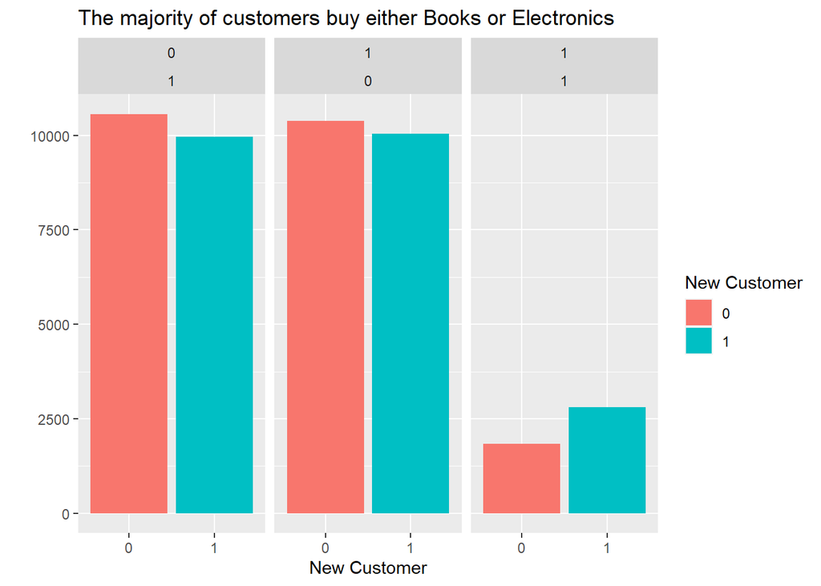

```r
    qplot(factor(new_customer), fill=factor(new_customer), data=dt.em, geom="bar")+ facet_grid(~ books + electronics) +
  labs(title = "The majority of customers buy either Books or Electronics",
              #subtitle = "Plot of length by dose",
              #caption = "Data source: ToothGrowth",
              x = "New Customer", y = "", fill="New Customer")
```

```r
stargazer(dt.em , type = "text")
```

```
##
## ==========================================================================
## Statistic         N     Mean   St. Dev.  Min   Pctl(25) Pctl(75)    Max
## --------------------------------------------------------------------------
## last_purchase   45,572  5.764   3.505     1       2        9        12
## hist_spend      45,572 241.555 254.597  29.990  64.840  325.202  3,345.930
## books           45,572  0.550   0.498     0       0        1         1
## electronics     45,572  0.552   0.497     0       0        1         1
## new_customer    45,572  0.500   0.500     0       0        1         1
## visit_after     45,572  0.148   0.355     0       0        0         1
## purchased_after 45,572  0.009   0.094     0       0        0         1
## spend_after     45,572  1.022   14.607    0       0        0        499
## --------------------------------------------------------------------------
```

```r
dt.em[treatment != "Books Email", t.test(last_purchase ~ treatment)]
```

```
##
##  Welch Two Sample t-test
##
## data:  last_purchase by treatment
## t = 0.60336, df = 30279, p-value = 0.5463
## alternative hypothesis: true difference in means is not equal to 0
## 95 percent confidence interval:
##  -0.05456909  0.10310618
## sample estimates:
## mean in group Electronics Email          mean in group No Email
##                        5.764982                        5.740714
```

```r
dt.em[treatment != "Books Email", t.test(hist_spend ~ treatment)]
```

```
##
##  Welch Two Sample t-test
##
## data:  hist_spend by treatment
## t = 0.6871, df = 30245, p-value = 0.492
## alternative hypothesis: true difference in means is not equal to 0
## 95 percent confidence interval:
##  -3.730161  7.757002
## sample estimates:
## mean in group Electronics Email          mean in group No Email
##                        241.9132                        239.8998
```

```r
dt.em[treatment != "Books Email", t.test(books ~ treatment)]
```

```
##
##  Welch Two Sample t-test
##
## data:  books by treatment
## t = -0.4546, df = 30282, p-value = 0.6494
## alternative hypothesis: true difference in means is not equal to 0
## 95 percent confidence interval:
##  -0.013806495  0.008607807
## sample estimates:
## mean in group Electronics Email          mean in group No Email
##                       0.5485729                       0.5511723
```

```r
dt.em[treatment != "Books Email", t.test(electronics ~ treatment)]
```

```
##
##  Welch Two Sample t-test
##
## data:  electronics by treatment
## t = 0.69207, df = 30282, p-value = 0.4889
## alternative hypothesis: true difference in means is not equal to 0
## 95 percent confidence interval:
##  -0.007245521  0.015154927
## sample estimates:
## mean in group Electronics Email          mean in group No Email
##                       0.5547977                       0.5508430
```

```r
dt.em[treatment != "Books Email", t.test(new_customer ~ treatment)]
```

```
##
##  Welch Two Sample t-test
##
## data:  new_customer by treatment
## t = 0.22446, df = 30282, p-value = 0.8224
## alternative hypothesis: true difference in means is not equal to 0
## 95 percent confidence interval:
##  -0.009973481  0.012553196
## sample estimates:
## mean in group Electronics Email          mean in group No Email
##                       0.5010264                       0.4997366
```

```r
dt.em[treatment != "Books Email", t.test(visit_after ~ treatment)]
```

```
##
##  Welch Two Sample t-test
##
## data:  visit_after by treatment
## t = 20.164, df = 28637, p-value < 2.2e-16
## alternative hypothesis: true difference in means is not equal to 0
## 95 percent confidence interval:
##  0.07333789 0.08913065
## sample estimates:
## mean in group Electronics Email          mean in group No Email
##                       0.1862791                       0.1050448
```

```r
dt.em[treatment != "Books Email", t.test(purchased_after ~ treatment)]
```

```
##
##  Welch Two Sample t-test
##
## data:  purchased_after by treatment
## t = 6.9367, df = 25794, p-value = 4.109e-12
## alternative hypothesis: true difference in means is not equal to 0
## 95 percent confidence interval:
##  0.005437086 0.009719892
## sample estimates:
## mean in group Electronics Email          mean in group No Email
##                     0.012913052                     0.005334563
```

```r
dt.em[treatment != "Books Email", t.test(spend_after ~ treatment)]
```

```
##
##  Welch Two Sample t-test
##
## data:  spend_after by treatment
## t = 4.6341, df = 26073, p-value = 3.602e-06
## alternative hypothesis: true difference in means is not equal to 0
## 95 percent confidence interval:
##  0.4463453 1.1006734
## sample estimates:
## mean in group Electronics Email          mean in group No Email
##                       1.3957367                       0.6222273
```

```r
dt.em[treatment != "Electronics Email", t.test(last_purchase ~ treatment)]
```

```
##
##  Welch Two Sample t-test
##
## data:  last_purchase by treatment
## t = 1.1553, df = 30469, p-value = 0.248
## alternative hypothesis: true difference in means is not equal to 0
## 95 percent confidence interval:
##  -0.03229262  0.12501277
## sample estimates:
## mean in group Books Email    mean in group No Email
##                  5.787074                  5.740714
```

```r
dt.em[treatment != "Electronics Email", t.test(hist_spend ~ treatment)]
```

```
##
##  Welch Two Sample t-test
##
## data:  hist_spend by treatment
## t = 1.0177, df = 30468, p-value = 0.3088
## alternative hypothesis: true difference in means is not equal to 0
## 95 percent confidence interval:
##  -2.726253  8.614625
## sample estimates:
## mean in group Books Email    mean in group No Email
##                  242.8440                  239.8998
```

```r
dt.em[treatment != "Electronics Email", t.test(books ~ treatment)]
```

```
##
##  Welch Two Sample t-test
##
## data:  books by treatment
## t = -0.19248, df = 30468, p-value = 0.8474
## alternative hypothesis: true difference in means is not equal to 0
## 95 percent confidence interval:
##  -0.01226828  0.01007417
## sample estimates:
## mean in group Books Email    mean in group No Email
##                 0.5500752                 0.5511723
```

```r
dt.em[treatment != "Electronics Email", t.test(electronics ~ treatment)]
```

```
##
##  Welch Two Sample t-test
##
## data:  electronics by treatment
## t = -0.04289, df = 30468, p-value = 0.9658
## alternative hypothesis: true difference in means is not equal to 0
## 95 percent confidence interval:
##  -0.01141546  0.01092657
## sample estimates:
## mean in group Books Email    mean in group No Email
##                 0.5505985                 0.5508430
```

```r
dt.em[treatment != "Electronics Email", t.test(new_customer ~ treatment)]
```

```
##
##  Welch Two Sample t-test
##
## data:  new_customer by treatment
## t = 0.16588, df = 30468, p-value = 0.8683
## alternative hypothesis: true difference in means is not equal to 0
## 95 percent confidence interval:
##  -0.01027864  0.01217923
## sample estimates:
## mean in group Books Email    mean in group No Email
##                 0.5006869                 0.4997366
```

```r
dt.em[treatment != "Electronics Email", t.test(visit_after ~ treatment)]
```

```
##
##  Welch Two Sample t-test
##
## data:  visit_after by treatment
## t = 12.664, df = 29763, p-value < 2.2e-16
## alternative hypothesis: true difference in means is not equal to 0
## 95 percent confidence interval:
##  0.04103574 0.05606381
## sample estimates:
## mean in group Books Email    mean in group No Email
##                 0.1535946                 0.1050448
```

```r
dt.em[treatment != "Electronics Email", t.test(purchased_after ~ treatment)]
```

```
##
##  Welch Two Sample t-test
##
## data:  purchased_after by treatment
## t = 3.521, df = 28917, p-value = 0.0004305
## alternative hypothesis: true difference in means is not equal to 0
## 95 percent confidence interval:
##  0.001492092 0.005239188
## sample estimates:
## mean in group Books Email    mean in group No Email
##               0.008700203               0.005334563
```

```r
dt.em[treatment != "Electronics Email", t.test(spend_after ~ treatment)]
```

```
##
##  Welch Two Sample t-test
##
## data:  spend_after by treatment
## t = 2.8376, df = 28559, p-value = 0.004548
## alternative hypothesis: true difference in means is not equal to 0
## 95 percent confidence interval:
##  0.1321767 0.7226032
## sample estimates:
## mean in group Books Email    mean in group No Email
##                 1.0496173                 0.6222273
```

We also need to make sure that both treatment groups are comparable between them, so the results of the experimentation will be valid. For the last 3 variables (visit_after, purchased_after , spend_after) the p-value is expected to be close to 0, since these are the output variables and it is expected that the variables behave differently across the two groups, otherwise the campaign wouldn’t have any result (e.g. a group of customers that receive an email campaign featuring electronics will probably spend more dollars than one that did not receive any email campaign). Again, all the tests yield a p-value greater than 0.1 (except, as expected, the last 3), therefore we can say that both treatments groups are comparable.

```r
dt.em[treatment != "No Email", t.test(last_purchase ~ treatment)]
```

```
##
##  Welch Two Sample t-test
##
## data:  last_purchase by treatment
## t = 0.54798, df = 30382, p-value = 0.5837
## alternative hypothesis: true difference in means is not equal to 0
## 95 percent confidence interval:
##  -0.05692716  0.10111023
## sample estimates:
##       mean in group Books Email mean in group Electronics Email
##                        5.787074                        5.764982
```

```r
dt.em[treatment != "No Email", t.test(hist_spend ~ treatment)]
```

```
##
##  Welch Two Sample t-test
##
## data:  hist_spend by treatment
## t = 0.31645, df = 30356, p-value = 0.7517
## alternative hypothesis: true difference in means is not equal to 0
## 95 percent confidence interval:
##  -4.834216  6.695747
## sample estimates:
##       mean in group Books Email mean in group Electronics Email
##                        242.8440                        241.9132
```

```r
dt.em[treatment != "No Email", t.test(books ~ treatment)]
```

```
##
##  Welch Two Sample t-test
##
## data:  books by treatment
## t = 0.26315, df = 30381, p-value = 0.7924
## alternative hypothesis: true difference in means is not equal to 0
## 95 percent confidence interval:
##  -0.009687279  0.012691849
## sample estimates:
##       mean in group Books Email mean in group Electronics Email
##                       0.5500752                       0.5485729
```

```r
dt.em[treatment != "No Email", t.test(electronics ~ treatment)]
```

```
##
##  Welch Two Sample t-test
##
## data:  electronics by treatment
## t = -0.73607, df = 30382, p-value = 0.4617
## alternative hypothesis: true difference in means is not equal to 0
## 95 percent confidence interval:
##  -0.015380802  0.006982506
## sample estimates:
##       mean in group Books Email mean in group Electronics Email
##                       0.5505985                       0.5547977
```

```r
dt.em[treatment != "No Email", t.test(new_customer ~ treatment)]
```

```
##
##  Welch Two Sample t-test
##
## data:  new_customer by treatment
## t = -0.05919, df = 30381, p-value = 0.9528
## alternative hypothesis: true difference in means is not equal to 0
## 95 percent confidence interval:
##  -0.01158396  0.01090483
## sample estimates:
##       mean in group Books Email mean in group Electronics Email
##                       0.5006869                       0.5010264
```

```r
dt.em[treatment != "No Email", t.test(visit_after ~ treatment)]
```

```
##
##  Welch Two Sample t-test
##
## data:  visit_after by treatment
## t = -7.5902, df = 30148, p-value = 3.287e-14
## alternative hypothesis: true difference in means is not equal to 0
## 95 percent confidence interval:
##  -0.04112477 -0.02424422
## sample estimates:
##       mean in group Books Email mean in group Electronics Email
##                       0.1535946                       0.1862791
```

```r
dt.em[treatment != "No Email", t.test(purchased_after ~ treatment)]
```

```
##
##  Welch Two Sample t-test
##
## data:  purchased_after by treatment
## t = -3.55, df = 29162, p-value = 0.0003859
## alternative hypothesis: true difference in means is not equal to 0
## 95 percent confidence interval:
##  -0.006538900 -0.001886798
## sample estimates:
##       mean in group Books Email mean in group Electronics Email
##                     0.008700203                     0.012913052
```

```r
dt.em[treatment != "No Email", t.test(spend_after ~ treatment)]
```

```
##
##  Welch Two Sample t-test
##
## data:  spend_after by treatment
## t = -1.8825, df = 29635, p-value = 0.05977
## alternative hypothesis: true difference in means is not equal to 0
## 95 percent confidence interval:
##  -0.70648799  0.01424922
## sample estimates:
##       mean in group Books Email mean in group Electronics Email
##                        1.049617                        1.395737
```

## Analysis of the Experiment Design and Results

1. Which campaign performed the best overall, the Books version, or the Electronics version?

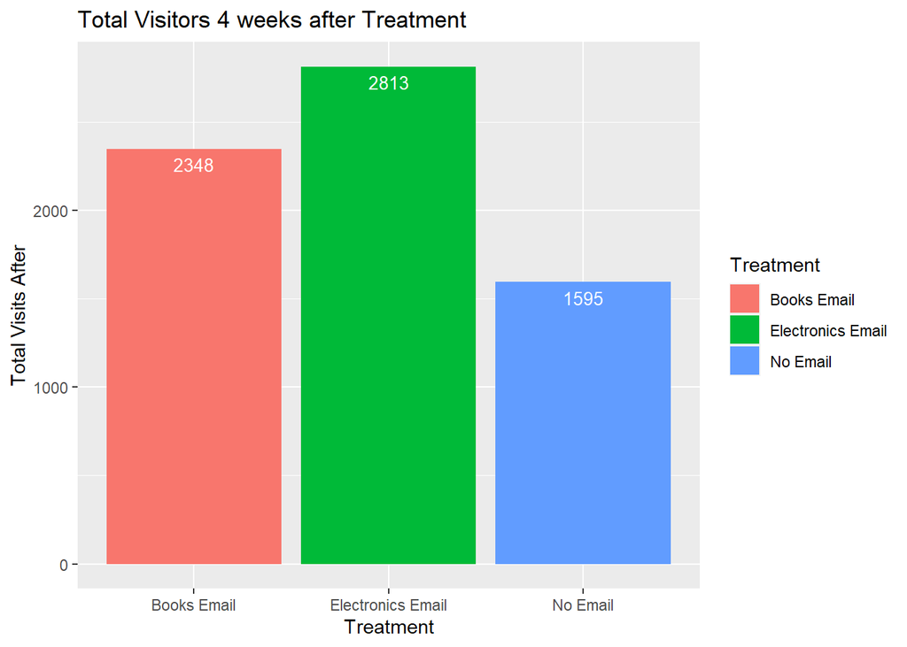

```r
    by.treatment = dt.em[, list(Total_Visit_after=sum(visit_after),
                                Total_Purchased_after=sum(purchased_after),
                                Total_Spend_after=sum(spend_after)), by="treatment"]

    ggplot(data=by.treatment, aes(x=factor(treatment), y=Total_Visit_after, fill=factor(treatment))) +
      geom_bar(stat="identity", position=position_dodge())+
      geom_text(aes(label=Total_Visit_after), vjust=1.6, color="white",
                position = position_dodge(0.9), size=3.5) + ggtitle("Total Number of Visitors 4 weeks after Treatment") +
      labs(title = "Total Visitors 4 weeks after Treatment",
              #subtitle = "Plot of length by dose",
              #caption = "Data source: ToothGrowth",
              x = "Treatment", y = "Total Visits After", fill="Treatment")
```

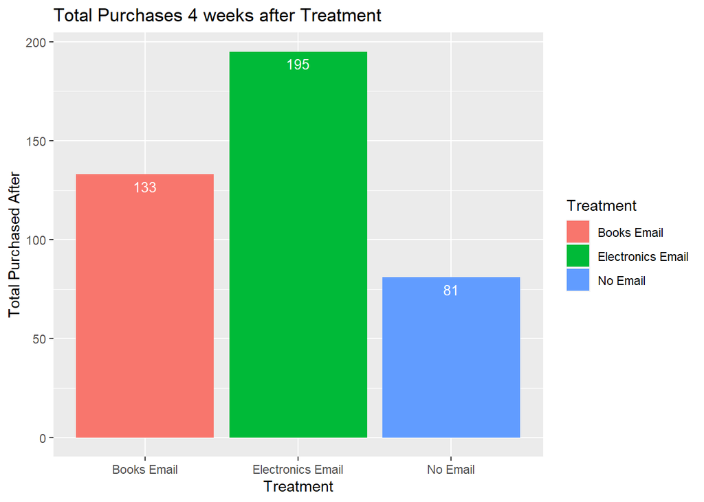

```r
    ggplot(data=by.treatment, aes(x=factor(treatment), y=Total_Purchased_after, fill=factor(treatment))) +
      geom_bar(stat="identity", position=position_dodge())+
      geom_text(aes(label=Total_Purchased_after), vjust=1.6, color="white",
                position = position_dodge(0.9), size=3.5) + ggtitle("Total Number of Purchases 4 weeks after Treatment") +
      labs(title = "Total Purchases 4 weeks after Treatment",
              #subtitle = "Plot of length by dose",
              #caption = "Data source: ToothGrowth",
              x = "Treatment", y = "Total Purchased After", fill="Treatment")
```

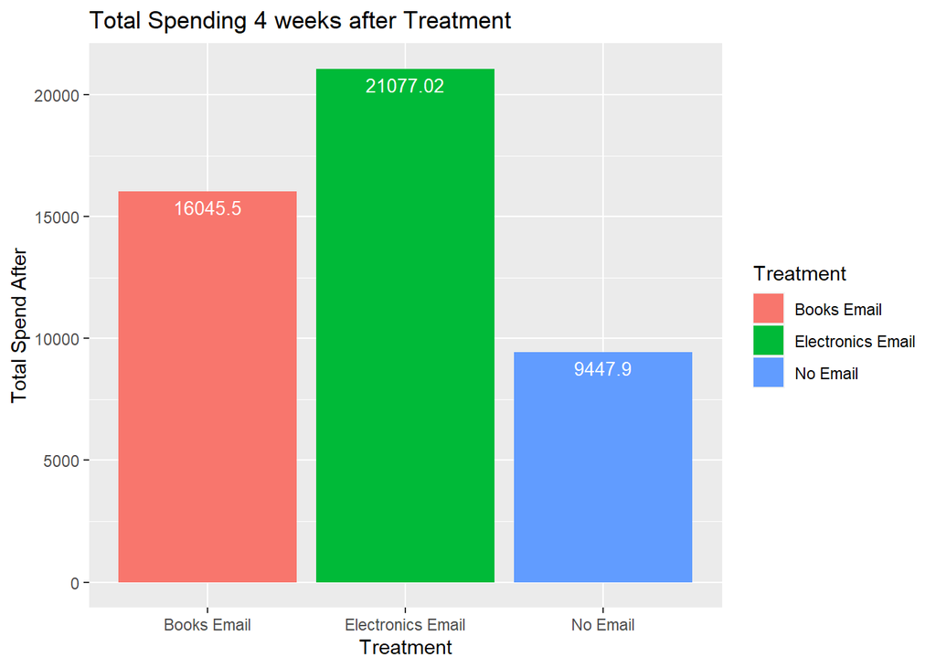

```r
    ggplot(data=by.treatment, aes(x=factor(treatment), y=Total_Spend_after, fill=factor(treatment))) +
      geom_bar(stat="identity", position=position_dodge())+
      geom_text(aes(label=Total_Spend_after), vjust=1.6, color="white",
                position = position_dodge(0.9), size=3.5) + ggtitle("Total Spending 4 weeks after Treatment") +
      labs(title = "Total Spending 4 weeks after Treatment",
              #subtitle = "Plot of length by dose",
              #caption = "Data source: ToothGrowth",
              x = "Treatment", y = "Total Spend After", fill="Treatment")
```

2. How much incremental sales per customer did the Books version of the campaign drive? How much incremental sales per customer did the Electronics version of the campaign drive?

```r
    # No email
    n_customer_no = length(dt.em[treatment=="No Email", new_customer])
    total_no_spend = dt.em[treatment=="No Email", sum(spend_after)]
    no_spend_per_customer = total_no_spend/n_customer_no
    percent_no = sum(dt.em[treatment == "No Email" , sum(spend_after)])/sum(dt.em$spend_after)*100

    n_customer_b = length(dt.em[treatment=="Books Email", new_customer])
    total_books_spend = dt.em[treatment=="Books Email", sum(spend_after)]
    books_spend_per_customer = total_books_spend/n_customer_b
    percent_books = sum(dt.em[treatment == "Books Email" , sum(spend_after)])/sum(dt.em$spend_after)*100
    cat("\nThe books version of the campaign yielded an incremental ", books_spend_per_customer-no_spend_per_customer, "€ per customer. With ", n_customer_b, " customers spending ", total_books_spend, "€. Which equates to ", percent_books,"% of the total sales 4 weeks after the experiment\n")
```

```
##
## The books version of the campaign yielded an incremental  0.42739 € per customer. With  15287  customers spending  16045.5 €. Which equates to  34.45427 % of the total sales 4 weeks after the experiment
```

```r
    n_customer_el = length(dt.em[treatment=="Electronics Email", new_customer])
    total_electronics_spend = dt.em[treatment=="Electronics Email", sum(spend_after)]
    electronics_spend_per_customer = total_electronics_spend/n_customer_el
    percent_electronics = sum(dt.em[treatment == "Electronics Email" , sum(spend_after)])/sum(dt.em$spend_after)*100
    cat("\nThe Electronics version of the campaign yielded an incremental ", electronics_spend_per_customer-no_spend_per_customer, "€ per customer. With ", n_customer_el, " customers spending ", total_electronics_spend, "€. Which equates to ", percent_electronics,"% of the total sales 4 weeks after the experiment")
```

```
##
## The Electronics version of the campaign yielded an incremental  0.7735094 € per customer. With  15101  customers spending  21077.02 €. Which equates to  45.25839 % of the total sales 4 weeks after the experiment
```

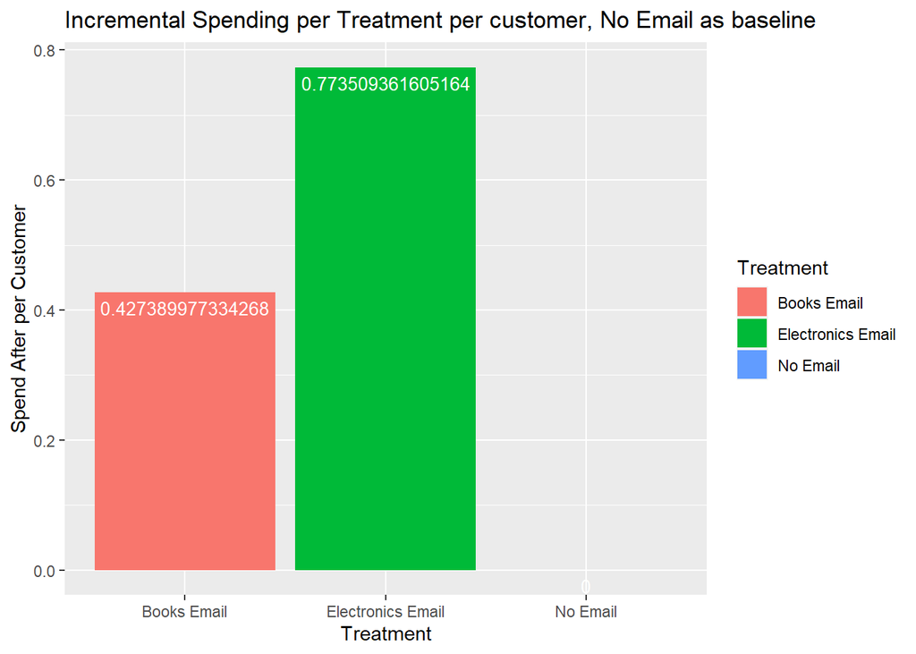

```r
    treatment = c("Books Email","Electronics Email", "No Email")
    values = c(books_spend_per_customer-no_spend_per_customer, electronics_spend_per_customer-no_spend_per_customer, no_spend_per_customer-no_spend_per_customer)
    data = data.frame(treatment, values)
    ggplot(data=data, aes(x=factor(treatment), y=values, fill=factor(treatment))) +
      geom_bar(stat="identity", position=position_dodge())+
      geom_text(aes(label=values), vjust=1.6, color="white",
                position = position_dodge(0.9), size=3.5) + ggtitle("Total Spending 4 weeks after Treatment") +
      labs(title = "Incremental Spending per Treatment per customer, No Email as baseline",
              #subtitle = "Plot of length by dose",
              #caption = "Data source: ToothGrowth",
              x = "Treatment", y = "Spend After per Customer", fill="Treatment")
```

3. Is cross-selling a good strategy for Books&Tech? In other words, which audience would you target the Books version to, and the Electronics version to, given the obtained results? Justify your recommendation.

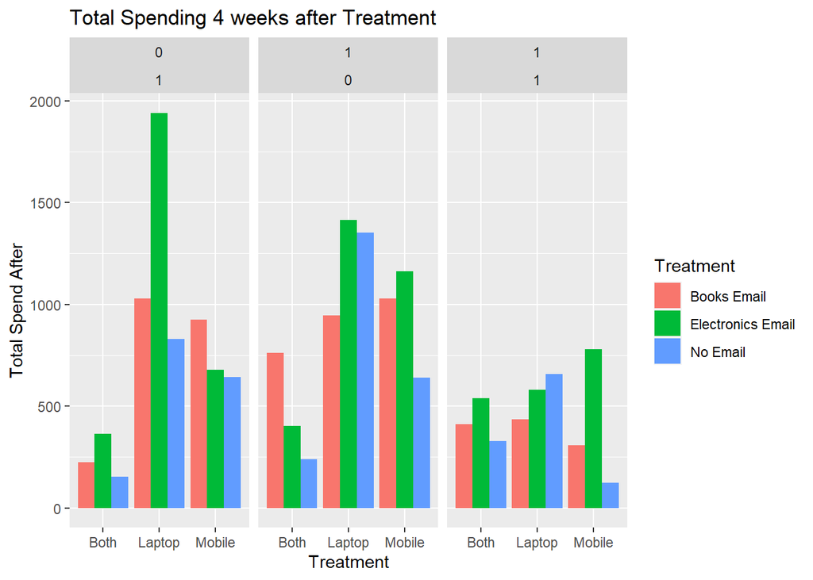

```r
    new.data = dt.em[, list(Total_Spend_after=sum(spend_after)), by=c("treatment","books","electronics","device","pop_density","new_customer")]
    labels_x = c("Books\nEmail"," Elect.\nEmail","No\nEmail")
    ggplot(data=new.data, aes(x=factor(device), y=Total_Spend_after, fill=factor(treatment))) + #scale_x_discrete(labels=labels_x) +
      geom_bar(stat="identity", position=position_dodge()) + facet_grid(~ books + electronics) +
      labs(title = "Total Spending 4 weeks after Treatment",
              #subtitle = "Plot of length by dose",
              #caption = "Data source: ToothGrowth",
              x = "Treatment", y = "Total Spend After", fill="Treatment")
```

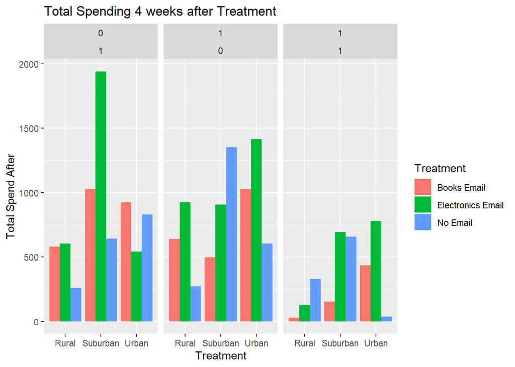

```r
    ggplot(data=new.data, aes(x=factor(pop_density), y=Total_Spend_after, fill=factor(treatment))) + #scale_x_discrete(labels=labels_x) +
      geom_bar(stat="identity", position=position_dodge()) + facet_grid(~ books + electronics) +
      labs(title = "Total Spending 4 weeks after Treatment",
              #subtitle = "Plot of length by dose",
              #caption = "Data source: ToothGrowth",
              x = "Treatment", y = "Total Spend After", fill="Treatment")
```

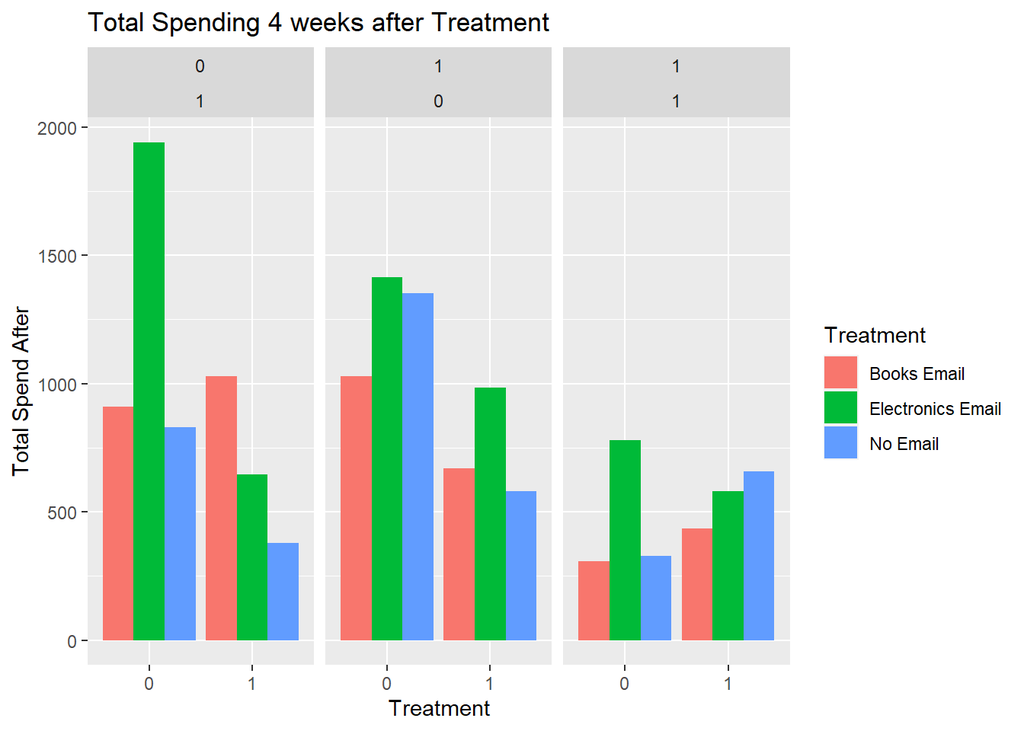

```r
    ggplot(data=new.data, aes(x=factor(new_customer), y=Total_Spend_after, fill=factor(treatment))) + #scale_x_discrete(labels=labels_x) +
      geom_bar(stat="identity", position=position_dodge()) + facet_grid(~ books + electronics) +
      labs(title = "Total Spending 4 weeks after Treatment",
              #subtitle = "Plot of length by dose",
              #caption = "Data source: ToothGrowth",
              x = "Treatment", y = "Total Spend After", fill="Treatment")
```